# Forecasting of Inbound Tourist Demand in Thailand: Assessing Recurrent Neural Networks

Author

Stefano Grassi

Published

March 2, 2025

## 1 Introduction

Forecasting inbound tourism demand is crucial for Thailand, where tourism contributes approximately 12% of GDP and employs over 20% of the workforce (Suthiwartnarueput, 2024). Accurate forecasts help Thai government agencies and the tourism industry optimize resource allocation, improve policy decisions and enhance strategic planning (Song et al., 2003). However, predicting tourism demand is challenging due to seasonality, volatility and non-linearity in the data, further exacerbated by external shocks such as COVID-19 (Gössling et al., 2020). Traditional statistical methods like Autoregressive Integrated Moving Average (ARIMA) and Exponential Smoothing (ETS) have been widely used in tourism forecasting, including for Thailand (Intarapak et al., 2022). While these methods are computationally efficient and interpretable, they often struggle to model complex temporal dependencies (Hyndman & Athanasopoulos, 2021), making it an opportunity to explore more advanced approaches. Deep Learning models, particularly Recurrent Neural Networks (RNN), have shown promise in time series forecasting due to their ability to capture sequential dependencies (Goodfellow et al., 2016). Their strong performance in forecasting competitions such as the M4 (Makridakis et al., 2018) has further driven interest in their application to Thai tourism data (Kosungnoen & Banditwattanawong, 2024). In this study, results demonstrate that RNN exhibits robust predictive power even with just 110 training observations, highlighting their potential. This research evaluates the effectiveness of different RNN units within a stacked architecture for univariate forecasting of inbound tourist demand in Thailand, implemented using Python.

## 2 Univariate Time Series Forecasting

Univariate time series forecasting (UTSF) focuses on predicting future values using only past observations of a single variable—in this case, the number of inbound tourists.

Mathematically, the forecasting problem (Equation 1) can be formulated as:

$$\hat{Y}_{t+1} = f(y_t, y_{t-1}, \dots, y_{t-n})
\tag{1}$$

where $\hat{Y}_{t+1}$ is the predicted number of inbound tourists at time $t+1$, $y_t, y_{t-1}, \dots, y_{t-n}$ represent the past $n$ observations of tourist arrivals, and $f(\cdot)$ is a function that models the relationship between past and future values. UTSF is computationally efficient and useful when external data is scarce or unreliable. However, it does not capture interactions between external drivers and the target variable, potentially limiting forecasting accuracy (Athanasopoulos & Silva, 2012). Despite this limitation, focusing on UTSF is of fundamental importance as it establishes a baseline for comparison, which is essential before exploring more advanced methods that incorporate external factors. Here, the focus is on a 3-step ahead forecast horizon, which is widely used in short-term forecasting and provides valuable insights for decision-makers and policymakers who base their quarterly planning on such forecasts, setting a rigorous stage for further research.

## 3 Dataset Overview

The dataset detailing the number of foreign tourists visiting Thailand is sourced from the official website of the Bank of Thailand, with data provided by the Economic Tourism and Sports Division, Ministry of Tourism and Sports (Bank of Thailand, n.d.). The Inbound Tourism Statistics of Thailand dataset consists of monthly records that are updated regularly. Figure 1 presents a univariate time series plot of inbound tourist arrivals spanning from January 2015 to August 2024, encompassing a total of 116 observations.

```python
# load required libraries
import pandas as pd
import numpy as np
import io

# Load the CSV, skipping metadata rows
file_path = './dataset/thai_inbound_tourists.csv'
th_tourist_demand_df = pd.read_csv(file_path,
                         encoding='TIS-620',
                         skiprows=5,
                         header=None)

# Set the first row as column headers
th_tourist_demand_df.columns = th_tourist_demand_df.iloc[0]  # Assign first row as headers
th_tourist_demand_df = th_tourist_demand_df[1:].reset_index(drop=True)  # Drop the first row

# Extract the row corresponding to "Number of foreign tourists visiting Thailand"
tourists_row = th_tourist_demand_df.iloc[0]  # First row after the header row

# Extract the month-year values as the index and clean them
month_years = tourists_row.iloc[2:].index.astype(str) \
               .str.strip() \
               .str.replace(r'\s*[a-zA-Z]$', '',
                regex=True)  # remove trailing single letters like 'r', 'p',

# Convert the values to a time series with the correct datetime index
th_tourists_set = pd.Series(
    tourists_row.iloc[2:].values,
    index=pd.to_datetime(month_years, format='%b %Y'),
    name="Inbound Tourists to Thailand (in thousands)"
).astype(float)
```

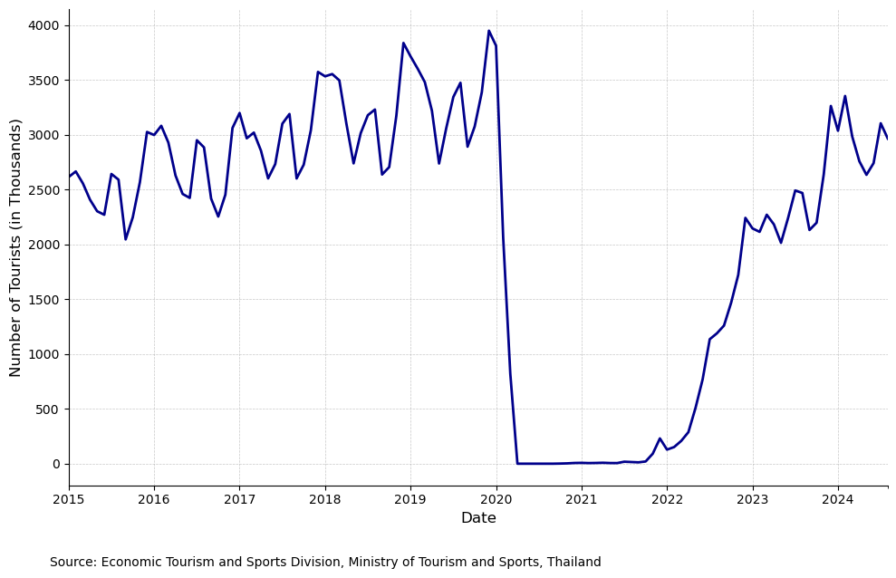

Figure 1: Inbound Tourists to Thailand (in Thousands)

## 4 Data Preprocessing

Preprocessing is a fundamental step in time series forecasting, extensively highlighted in the literature to ensure the robustness and reliability of model performance, particularly when working with RNN. Figure 2 illustrates the core preprocessing steps adopted in this study, which align with methodologies proposed by Bandara et al. (2020) and Hewamalage et al. (2021).

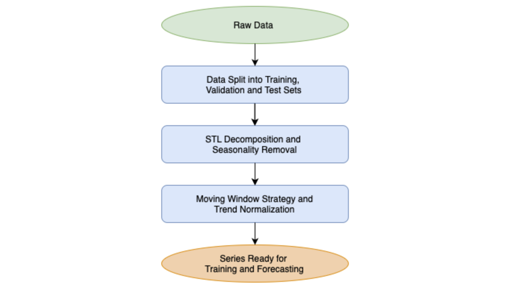

Figure 2: diagram illustrating the key data preprocessing steps undertaken.

### 4.1 Data Splitting

Following the methodology outlined by Hewamalage et al. (2021), the time series is divided into training, validation and test sets to ensure a structured evaluation. The most recent portion, corresponding to the 3-step ahead forecast horizon, is reserved as the test set. The validation set consists of the final segment of the remaining data, also matching the 3-step ahead forecast horizon in length. The rest of the series, comprising 110 observations, is used for training. This fixed-origin validation approach enables effective hyperparameter tuning, as described in Section 5.1.4. Instead of a rolling origin scheme, this method is chosen to align with standard competition frameworks and facilitate meaningful comparisons with both existing and newer research. After selecting the optimal hyperparameters, the model is retrained on the entire dataset (excluding only the unseen test set) and then evaluated on this final test set to provide an unbiased assessment of its forecasting performance.

```python
#--------------------

# Split Dataset

#--------------------

# Define helper function to split the dataset
def split_dataset(original_series, h):
    """
    Splits the time series into training and test sets
    based on the forecast horizon.

    Parameters:
    - original_series (pd.Series): The original time series data.
    - h (int): Forecast horizon (size of the test set).

    Returns:
    - train_set (pd.Series): The training set.
    - test_set (pd.Series): The test set.
    """

    # Ensure the series is sorted in ascending order by date
    original_series = original_series.sort_index(ascending=True)

    # Length of the series
    l = len(original_series)

    # The most recent `h` points are the test set
    test_set = original_series[-h:]

    # Training set: all data before the test set
    train_set = original_series[:-h]

    return train_set, test_set

# Forecast horizon (size of test set)
h = 3

# Split the dataset
train_set, test_set = split_dataset(th_tourists_set, h)
```